# Quantifying heterospecific vocal mimicry with deep learning: evidence from a bellbird

## Model training

[figure not shown]

[figure not shown]

[figure not shown]

[figure not shown]

[figure not shown]

[figure not shown]

[figure not shown]

[figure not shown]

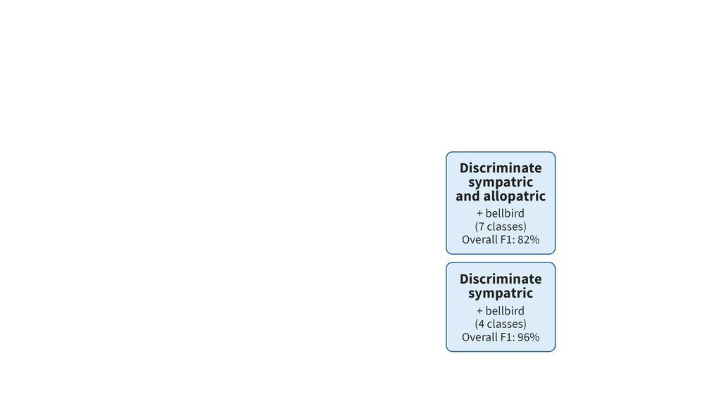

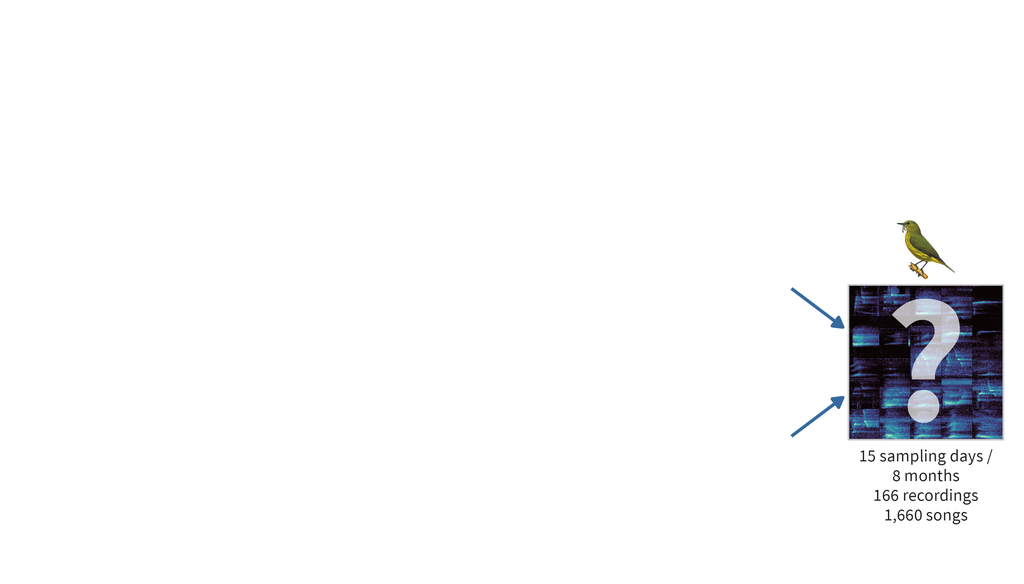

## Similarity to sympatric vs allopatric species

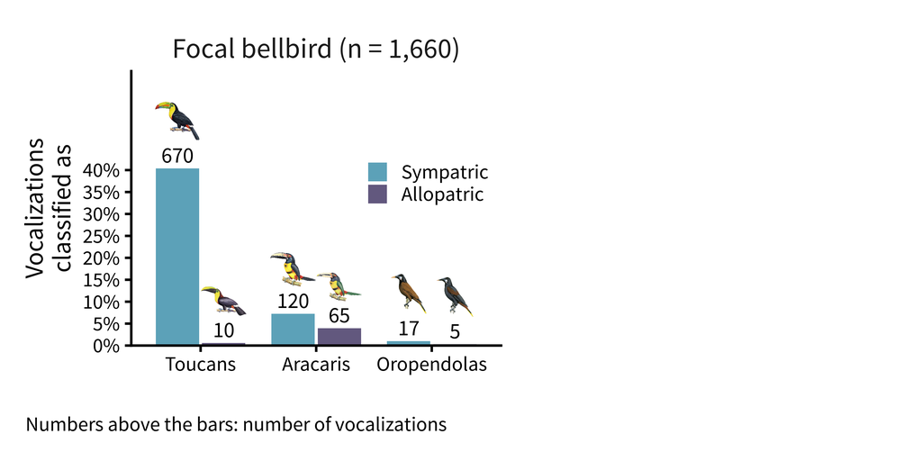

Focal bellbird: sympatric 10 times more than allopatric  
Other bellbirds: classified by models that never heard their recordings

## Similarity to sympatric vs allopatric species

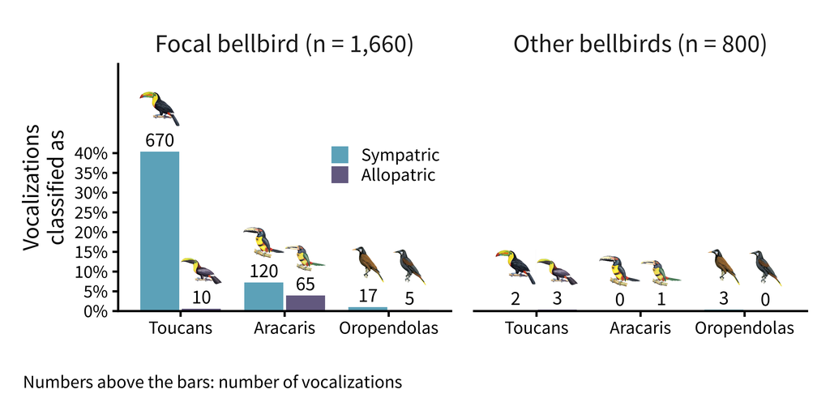

Focal bellbird: sympatric 10 times more than allopatric  
Other bellbirds: classified by models that never heard their recordings

## Similarity to sympatric species

[figure not shown]

## Change over time

[figure not shown]

## Implications

**Learning**  
Further evidence of vocal production learning in bellbirds

**Complexity**  
Vocal development comparable in complexity to that of songbirds

Mimicry could be a **transient** component of vocal development

## Credits and resources

**Funding**: Centro de Investigación en Neurociencias, Universidad de Costa Rica

**Bird illustrations**: Birds of the World (Cornell Lab of Ornithology)

**Photos**: David Jimenez

**Project site**: analyses, code and this presentation  
[marce10.github.io/bellbird_vocal_mimicry](https://marce10.github.io/bellbird_vocal_mimicry/)

[figure not shown]

**suwo**: recordings from online repositories in R  
[docs.ropensci.org/suwo](https://docs.ropensci.org/suwo/)

[figure not shown]

**BirdNET**: bird identification by sound with deep learning  
[birdnet.cornell.edu](https://birdnet.cornell.edu/)

[figure not shown]

**dynaSpec**: the spectrograms with sound in this presentation  
[marce10.github.io/dynaSpec](https://marce10.github.io/dynaSpec/)

References

[figure not shown]

This presentation

## References

1. BirdLife International and Handbook of the Birds of the World (2025). Bird species distribution maps of the world. Version 2025.2.
2. Dalziell, A. H., Welbergen, J. A., Igic, B. and Magrath, R. D. (2015). Avian vocal mimicry: a unified conceptual framework. *Biological Reviews* 90: 643–668.
3. Jarvis, E. D. (2004). Learned birdsong and the neurobiology of human language. *Annals of the New York Academy of Sciences* 1016: 749–777.
4. Kahl, S., Wood, C. and Klinck, H. (2025). BirdNET Model V2.4. Zenodo.
5. Kelley, L. A., Coe, R. L., Madden, J. R. and Healy, S. D. (2008). Vocal mimicry in songbirds. *Animal Behaviour* 76: 521–528.
6. Kroodsma, D. E. et al. (2013). Behavioral evidence for song learning in the suboscine bellbirds (*Procnias* spp.; Cotingidae). *The Wilson Journal of Ornithology* 125: 1–14.
7. McTavish, E. J. et al. (2025). A complete and dynamic tree of birds. *Proceedings of the National Academy of Sciences*.
8. Saranathan, V., Hamilton, D., Powell, G. V. N., Kroodsma, D. E. and Prum, R. O. (2007). Genetic evidence supports song learning in the three-wattled bellbird *Procnias tricarunculata*. *Molecular Ecology* 16: 3689–3702.
9. Ten Cate, C. (2021). Re-evaluating vocal production learning in non-oscine birds. *Philosophical Transactions of the Royal Society B* 376: 20200249.

← Back to resources

## Discriminating sympatric + allopatric species

[figure not shown]

5,517 vocalizations, 5-fold cross-validation (each classified by a model that never heard its recording)

## Discriminating sympatric species

[figure not shown]